# Tarea_Daniela_Lopez

Daniela Lopez

2022-07-17

```r
install.packages("readxl")
install.packages("dplyr")
```

```r
install.packages("ggplot2")
install.packages("graphics")
install.packages("survminer")
install.packages("survival")
install.packages("ggpubr")
install.packages("tidyverse")
install.packages("multcomp")
install.packages("car")
install.packages("psych")
install.packages("stat")
install.packages("knitr")
install.packages("broom")
install.packages("lmtets")
install.packages("pander")
install.packages("tidyr")
install.packages("zoo")
install.packages("ROSE")
install.packages("factoextra")
```

## Analisis exploratorio de los datos

Se cuentan con 3 datas: 1.- Medicion de Cuerpos de Inclusion (CI): estos corresponden a datos cuantitativos continuos (tamaño). 2.- Superviviencia: Data de supervivencia, (1-0). Variable dicotomica. 3.- Analisis de expresion de genes (CT): datos cuantitativos conitnuos.

Primero se crean objetos con la data

```r
CI_diametro <- read_excel ("Datos_Medicion_IBs.xlsx", sheet = "Datos diametro")
CI_Longitud <- read_excel("Datos_Medicion_IBs.xlsx", sheet = " Datos longitud")
sobrevivencia <- read_excel("Datos_Sobrevivencia.xlsx", sheet = "General")
Sobrevivencia_CI <- read_excel("Datos_Sobrevivencia.xlsx", sheet = "Especifico")
exp_gen <- read_excel("Datos_expresion_genica.xlsx", sheet = "CT_PROM")
```

```r
head (CI_diametro)
```

```
## # A tibble: 6 × 3
##       N Proteina `diametro (nm)`
##   <dbl> <chr>              <dbl>
## 1     1 TNF-a               693.
## 2     2 TNF-a               694.
## 3     3 TNF-a               748.
## 4     4 TNF-a               610.
## 5     5 TNF-a               621.
## 6     6 TNF-a               561.
```

```r
summary (CI_diametro)
```

```
##        N           Proteina         diametro (nm)
##  Min.   :  1.0   Length:908         Min.   :  92.01
##  1st Qu.: 76.0   Class :character   1st Qu.: 605.38
##  Median :152.0   Mode  :character   Median : 688.80
##  Mean   :151.8                      Mean   : 799.99
##  3rd Qu.:227.2                      3rd Qu.:1057.53
##  Max.   :303.0                      Max.   :1543.91
```

```r
head (CI_Longitud)
```

```
## # A tibble: 6 × 3
##       N Proteina `longitud (nm)`
##   <dbl> <chr>              <dbl>
## 1     1 TNF-a               944.
## 2     2 TNF-a               869.
## 3     3 TNF-a              1094.
## 4     4 TNF-a              1056.
## 5     5 TNF-a              1197.
## 6     6 TNF-a              1184.
```

```r
summary (CI_Longitud)
```

```
##        N           Proteina         longitud (nm)
##  Min.   :  1.0   Length:659         Min.   : 462.4
##  1st Qu.: 55.5   Class :character   1st Qu.: 902.5
##  Median :134.0   Mode  :character   Median :1052.0
##  Mean   :138.7                      Mean   :1190.5
##  3rd Qu.:216.5                      3rd Qu.:1222.2
##  Max.   :305.0                      Max.   :4977.6
```

```r
head (sobrevivencia)
```

```
## # A tibble: 6 × 6
##       N Fish  Hours Protein `Dosis (mg)` Sobrevivencia
##   <dbl> <chr> <dbl> <chr>          <dbl>         <dbl>
## 1     1 P1       20 Control            0             1
## 2     2 P2       20 Control            0             1
## 3     3 P3       20 Control            0             1
## 4     4 P4       20 Control            0             1
## 5     5 P5       20 Control            0             1
## 6     6 P6       20 Control            0             1
```

```r
summary (sobrevivencia)
```

```
##        N             Fish               Hours          Protein
##  Min.   : 1.00   Length:52          Min.   : 20.00   Length:52
##  1st Qu.:13.75   Class :character   1st Qu.: 39.00   Class :character
##  Median :26.50   Mode  :character   Median :100.00   Mode  :character
##  Mean   :26.50                      Mean   : 77.54
##  3rd Qu.:39.25                      3rd Qu.:100.00
##  Max.   :52.00                      Max.   :100.00
##    Dosis (mg)      Sobrevivencia
##  Min.   :0.00000   Min.   :0.0000
##  1st Qu.:0.05625   1st Qu.:0.0000
##  Median :0.11250   Median :0.0000
##  Mean   :0.12837   Mean   :0.3077
##  3rd Qu.:0.15000   3rd Qu.:1.0000
##  Max.   :0.30000   Max.   :1.0000
```

```r
head (Sobrevivencia_CI)
```

```
## # A tibble: 6 × 7
##       N Fish  Analista Protein `Dosis (mg)`  Hour Sobrevivencia
##   <dbl> <chr> <chr>    <chr>          <dbl> <dbl>         <dbl>
## 1     1 P1    DT       control            0     9             1
## 2     2 P2    DT       control            0     9             1
## 3     3 P3    DT       control            0    23             1
## 4     4 P4    DT       control            0    23             1
## 5     5 P5    DT       control            0    23             1
## 6     6 P6    DT       control            0    23             1
```

```r
summary (Sobrevivencia_CI)
```

```
##        N              Fish             Analista           Protein
##  Min.   :  1.00   Length:104         Length:104         Length:104
##  1st Qu.: 26.75   Class :character   Class :character   Class :character
##  Median : 52.50   Mode  :character   Mode  :character   Mode  :character
##  Mean   : 52.50
##  3rd Qu.: 78.25
##  Max.   :104.00
##    Dosis (mg)           Hour       Sobrevivencia
##  Min.   :  0.000   Min.   : 9.00   Min.   :0.0000
##  1st Qu.:  0.075   1st Qu.:23.00   1st Qu.:0.0000
##  Median :  0.300   Median :96.00   Median :0.0000
##  Mean   : 82.313   Mean   :70.96   Mean   :0.3654
##  3rd Qu.:150.000   3rd Qu.:96.00   3rd Qu.:1.0000
##  Max.   :300.000   Max.   :96.00   Max.   :1.0000
```

```r
head (exp_gen)
```

```
## # A tibble: 6 × 7
##   Sample Tissue          `Day Challenge` TREATMENT Group   Gen         CT
##    <dbl> <chr>                     <dbl> <chr>     <chr>   <chr>    <dbl>
## 1   5783 Anterior kidney              15 UNVACC    CALPSUM B2M_PROM  22.3
## 2   5789 Anterior kidney              15 UNVACC    CALPSUM B2M_PROM  21.0
## 3   5790 Anterior kidney              NA UNVACC    CALPSUM B2M_PROM  16.1
## 4   5797 Anterior kidney              15 UNVACC    CALPSUM B2M_PROM  20.2
## 5   5799 Anterior kidney              NA UNVACC    CALPSUM B2M_PROM  14.6
## 6   5818 Anterior kidney              14 UNVACC    CALPSUM B2M_PROM  21.4
```

```r
summary (exp_gen)
```

```
##      Sample        Tissue          Day Challenge    TREATMENT
##  Min.   :5783   Length:246         Min.   :14.00   Length:246
##  1st Qu.:5818   Class :character   1st Qu.:15.00   Class :character
##  Median :6809   Mode  :character   Median :15.00   Mode  :character
##  Mean   :7029                      Mean   :20.86
##  3rd Qu.:7847                      3rd Qu.:29.00
##  Max.   :8850                      Max.   :31.00
##                                    NA's   :72
##     Group               Gen                  CT
##  Length:246         Length:246         Min.   :10.77
##  Class :character   Class :character   1st Qu.:19.94
##  Mode  :character   Mode  :character   Median :23.14
##                                        Mean   :22.86
##                                        3rd Qu.:26.34
##                                        Max.   :31.95
##
```

# Determinar si existe algún desbalance en los datos

```r
table(CI_diametro$Proteina)
```

```
##
##     IL-6    TNF-a TNF-a pH
##      303      303      302
```

```r
knitr::kable(table(CI_diametro$Proteina), caption= "Tabla 1. Diametro (nm) de los CI")
```

Tabla 1. Diametro (nm) de los CI

| Var1 | Freq |
| --- | --- |
| IL-6 | 303 |
| TNF-a | 303 |
| TNF-a pH | 302 |

```r
prop.table(table(CI_diametro$Proteina))
```

```
##
##      IL-6     TNF-a  TNF-a pH
## 0.3337004 0.3337004 0.3325991
```

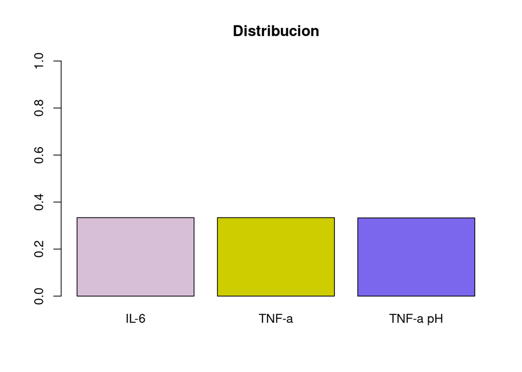

```r
barplot(prop.table(table(CI_diametro$Proteina)),
        col = c("thistle", "yellow3", "slateblue2"),
        ylim = c(0, 1),
        main = "Distribucion")
```

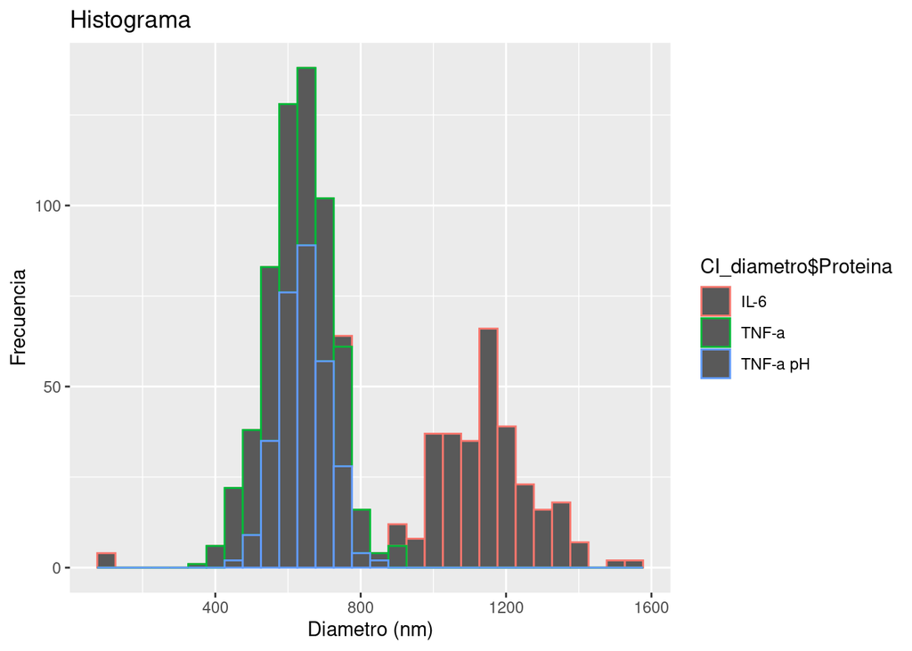

```r
ggplot(CI_diametro, aes(x = CI_diametro$`diametro (nm)`), position = "identity", bins = 15, alpha = 1) +
  labs(title="Histograma", x="Diametro (nm)",
       y="Frecuencia") +
  geom_histogram(aes(color = CI_diametro$Proteina))
```

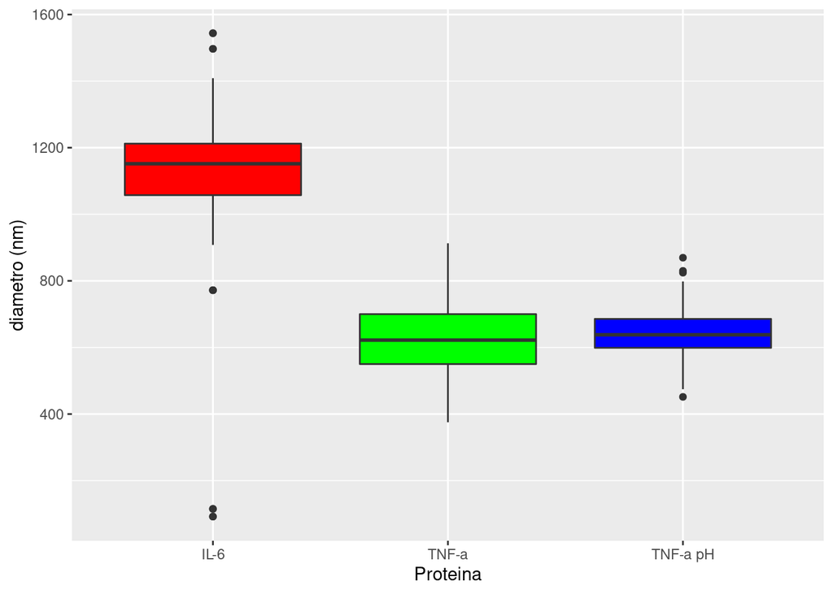

```r
ggplot(data = CI_diametro, aes(x = Proteina, y = `diametro (nm)`)) +
geom_boxplot(fill = rainbow(3))
```

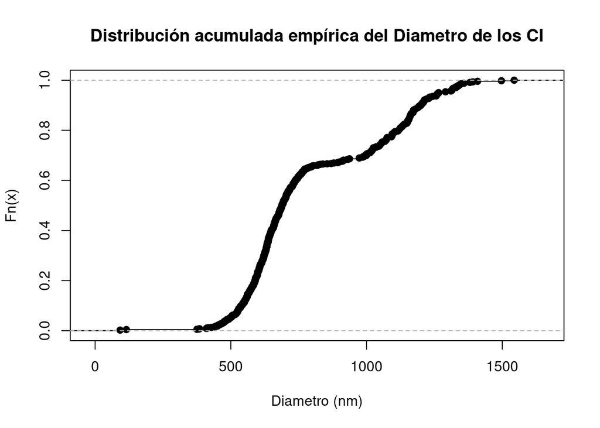

```r
plot(ecdf(CI_diametro$`diametro (nm)`), main= "Distribución acumulada empírica del Diametro de los CI", xlab="Diametro (nm)")
```

La proteina IL-6 Presenta los mayores diametros, mientras que parece que el pH no afecta el diametro de la proteína TNF.

```r
table(CI_Longitud$Proteina)
```

```
##
##     IL-6    TNF-a TNF-a pH
##       62      305      292
```

```r
knitr::kable(table(CI_Longitud$Proteina), caption= "Tabla 2. Longitud (nm) de los CI")
```

Tabla 2. Longitud (nm) de los CI

| Var1 | Freq |
| --- | --- |
| IL-6 | 62 |
| TNF-a | 305 |
| TNF-a pH | 292 |

```r
prop.table(table(CI_Longitud$Proteina))
```

```
##
##       IL-6      TNF-a   TNF-a pH
## 0.09408194 0.46282246 0.44309560
```

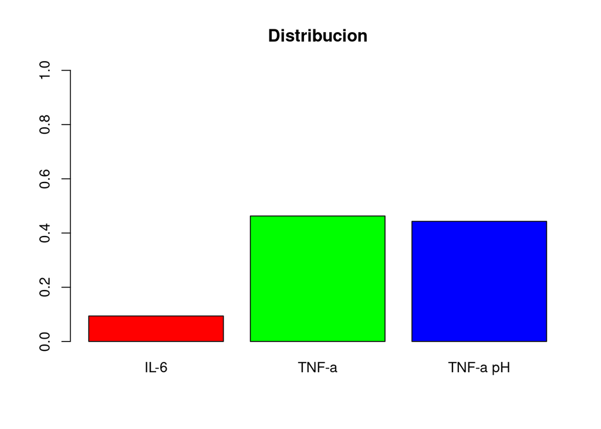

```r
barplot(prop.table(table(CI_Longitud$Proteina)),
        col = rainbow(3),
        ylim = c(0, 1),
        main = "Distribucion")
```

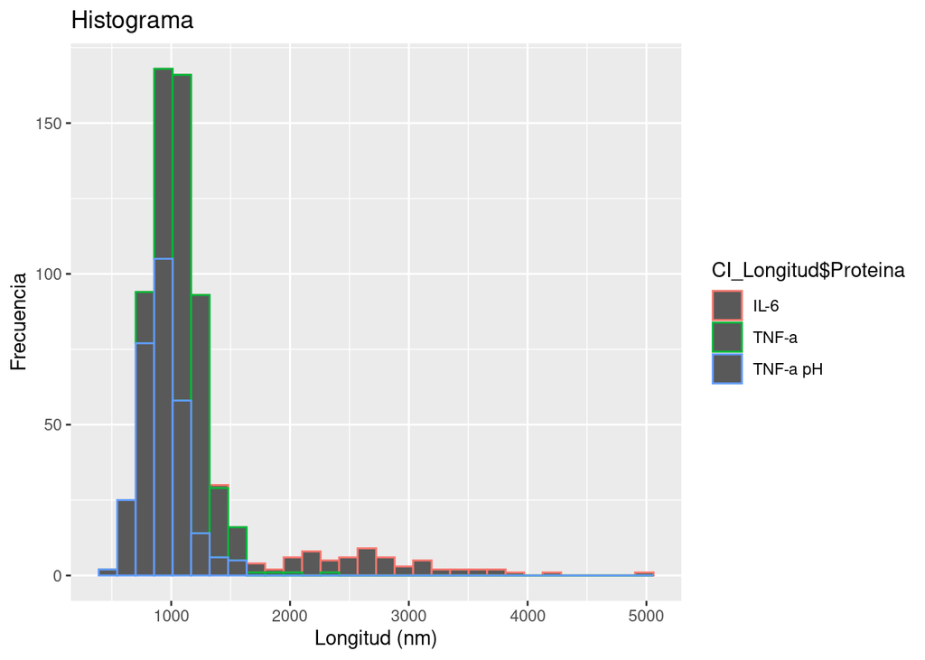

```r
ggplot(CI_Longitud, aes(x = CI_Longitud$`longitud (nm)`), position = "identity", bins = 15, alpha = 1) +
  labs(title="Histograma", x="Longitud (nm)",
       y="Frecuencia")+
  geom_histogram(aes(color = CI_Longitud$Proteina))
```

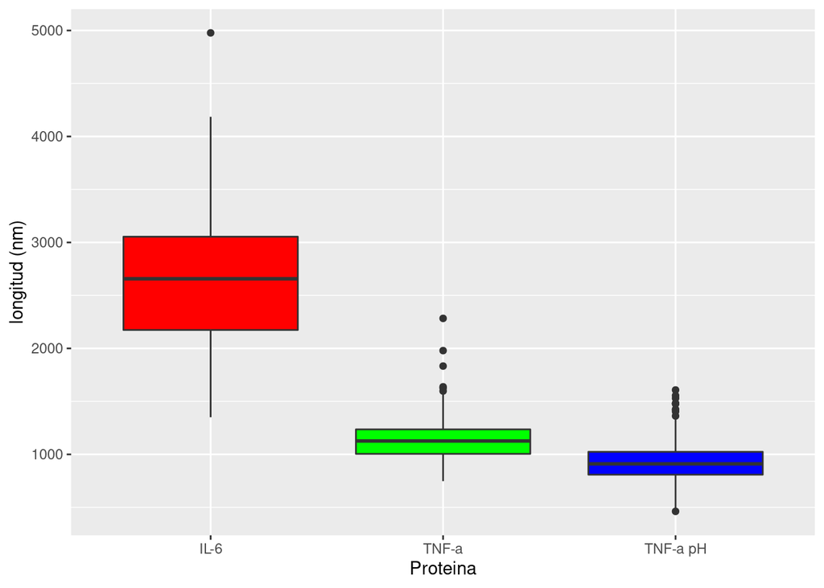

```r
ggplot(data = CI_Longitud, aes(x = Proteina, y = `longitud (nm)`)) +
geom_boxplot(fill = rainbow(3))
```

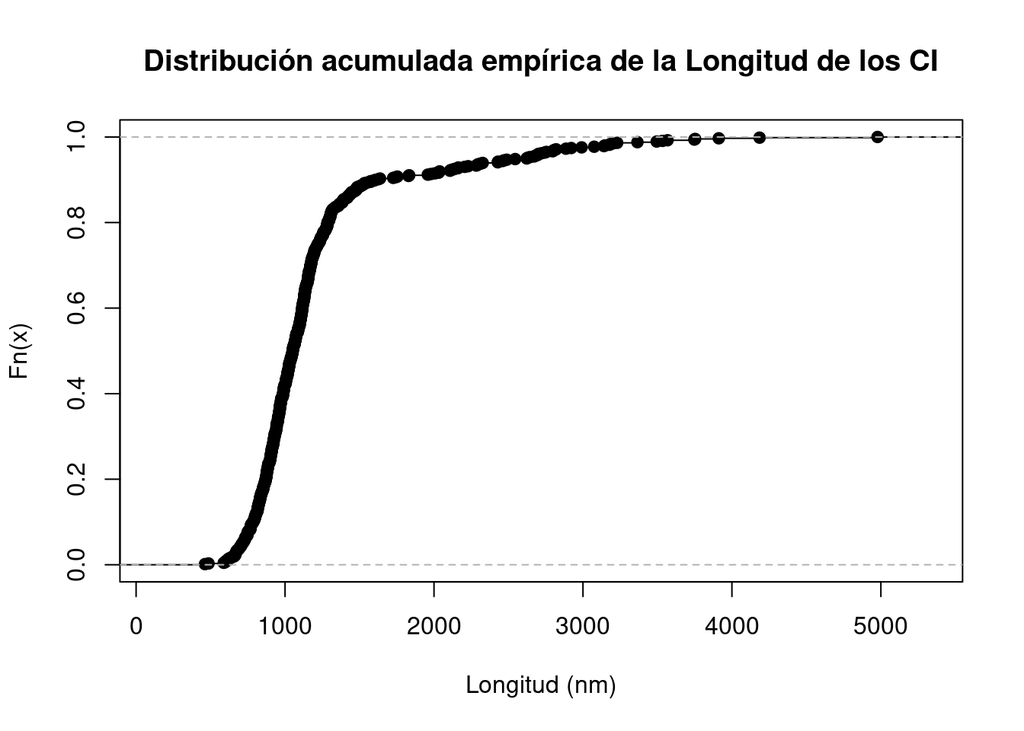

```r
plot(ecdf(CI_Longitud$`longitud (nm)`), main= "Distribución acumulada empírica de la Longitud de los CI", xlab="Longitud (nm)")
```

Los datos no estan balanceados, la data esta representada por un 9,4% de la proteína IL-6, y es la proteína IL-6 quiene presenta la mayor longitud. En todos los casos se presentan valores fuera de tendencia, IL-6tiene una medida muy por encima de la media, que representa casi el doble, mientras que TNF-a tiene 5 medidas por encima de la media, siendo la maxima casi el doble de la media central, TNF-a pH tiene un valor por debajo de la media y 5 valores por encima de la media. Dado la cantidad de valores atipicos, se deberá evaluar si su eliminación no afecta los resultados en pruebas posteriores.

La proteina IL-6 Presenta las mayores longitudes, pero esta poco representada.

Observacion parcial: aparentemente IL-6 tiene un menor rendimiento debido al tamaño de las proteínas, ya que es la que presenta mayor diametro y longitud.

```r
table(exp_gen$Gen)
```

```
##
##  B2M_PROM CATH_PROM IL1B_PROM  IL8_PROM   NK_PROM TNFa_PROM
##        41        41        41        41        41        41
```

```r
knitr::kable(table(exp_gen$Gen, exp_gen$TREATMENT), caption= "Tabla 3. Genes Expresados durante coinfeccion con P. salmonis")
```

Tabla 3. Genes Expresados durante coinfeccion con P. salmonis

|  | UNVACC | VACCINATED |
| --- | --- | --- |
| B2M_PROM | 17 | 24 |
| CATH_PROM | 17 | 24 |
| IL1B_PROM | 17 | 24 |
| IL8_PROM | 17 | 24 |
| NK_PROM | 17 | 24 |
| TNFa_PROM | 17 | 24 |

```r
prop.table(table(exp_gen$Gen))
```

```
##
##  B2M_PROM CATH_PROM IL1B_PROM  IL8_PROM   NK_PROM TNFa_PROM
## 0.1666667 0.1666667 0.1666667 0.1666667 0.1666667 0.1666667
```

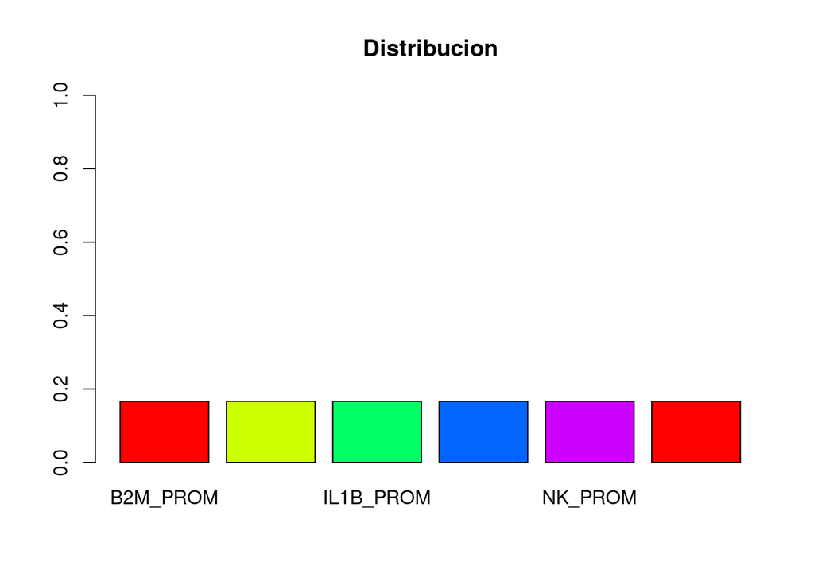

```r
barplot(prop.table(table(exp_gen$Gen)),
        col = rainbow(5),
        ylim = c(0, 1),
        main = "Distribucion")
```

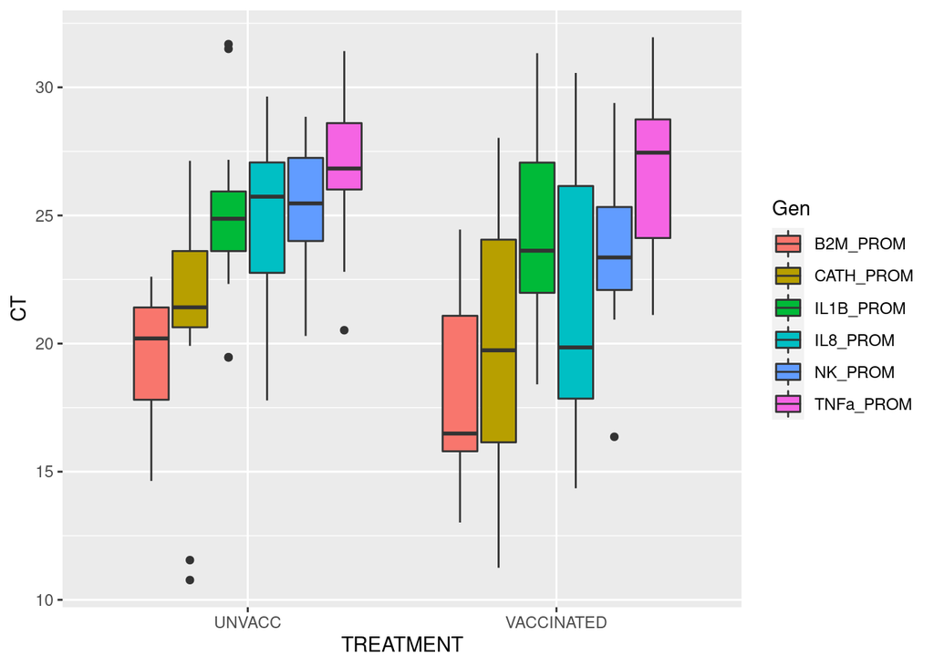

```r
ggplot(data = exp_gen, aes(x=TREATMENT, y=CT, fill=Gen)) +
geom_boxplot()+
  labs(y="CT")
```

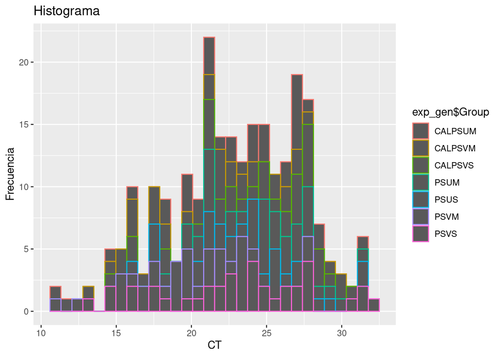

```r
ggplot(exp_gen, aes(x = exp_gen$CT), position = "identity", bins = 15, alpha = 1) +
  labs(title="Histograma", x="CT",
       y="Frecuencia") +
  geom_histogram(aes(color = exp_gen$Group))
```

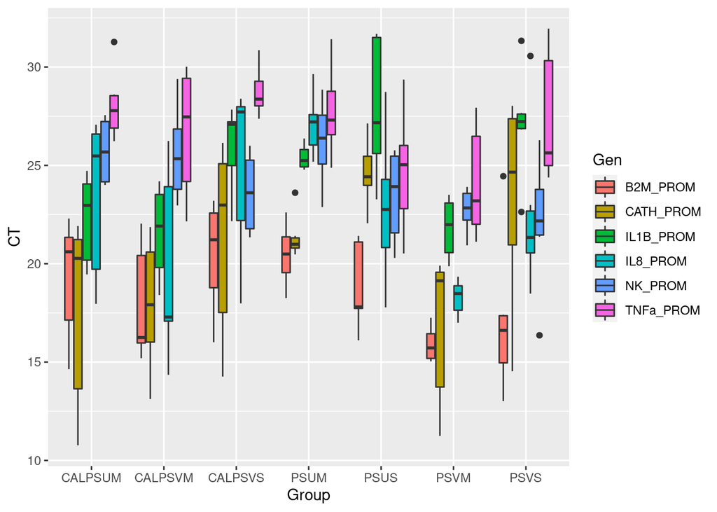

```r
ggplot(data = exp_gen, aes(x=Group, y=CT, fill=Gen)) +
geom_boxplot()+
  labs(y="CT")
```

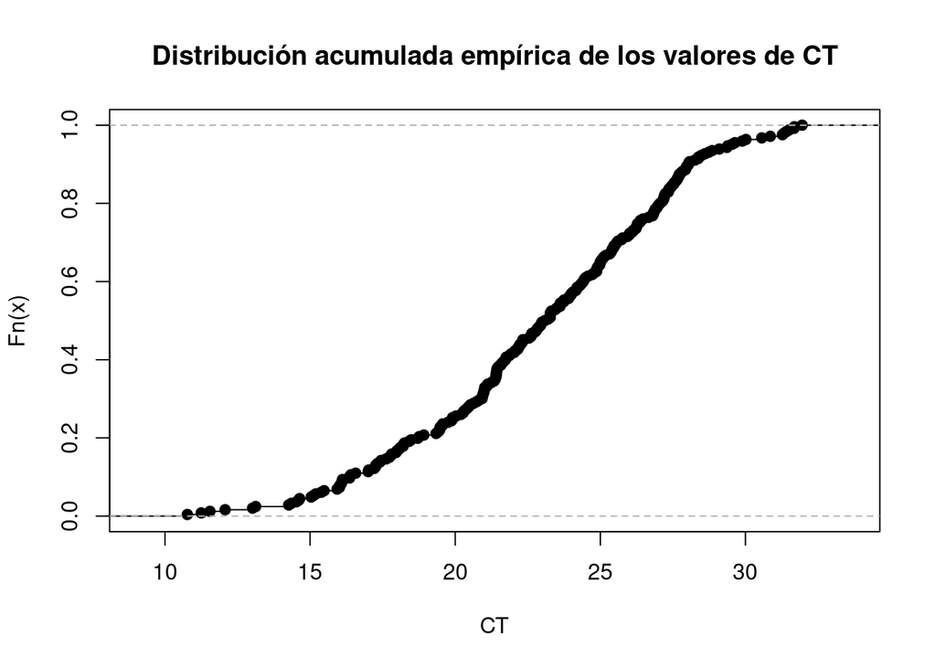

```r
plot(ecdf(exp_gen$CT), main= "Distribución acumulada empírica de los valores de CT", xlab="CT")
```

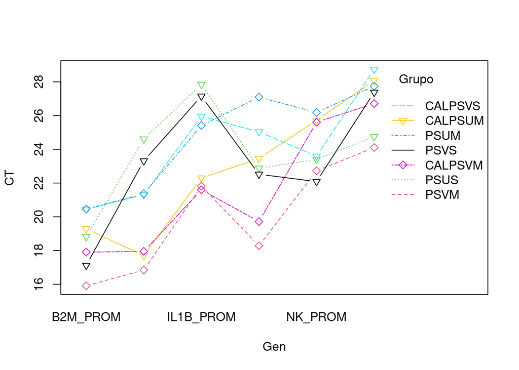

```r
interaction.plot(exp_gen$Gen,exp_gen$Group, exp_gen$CT,  fun=mean, xlab= "Gen", ylab= "CT", col=15:1, pch=c(6,5), type="b", trace.label="Grupo")
```

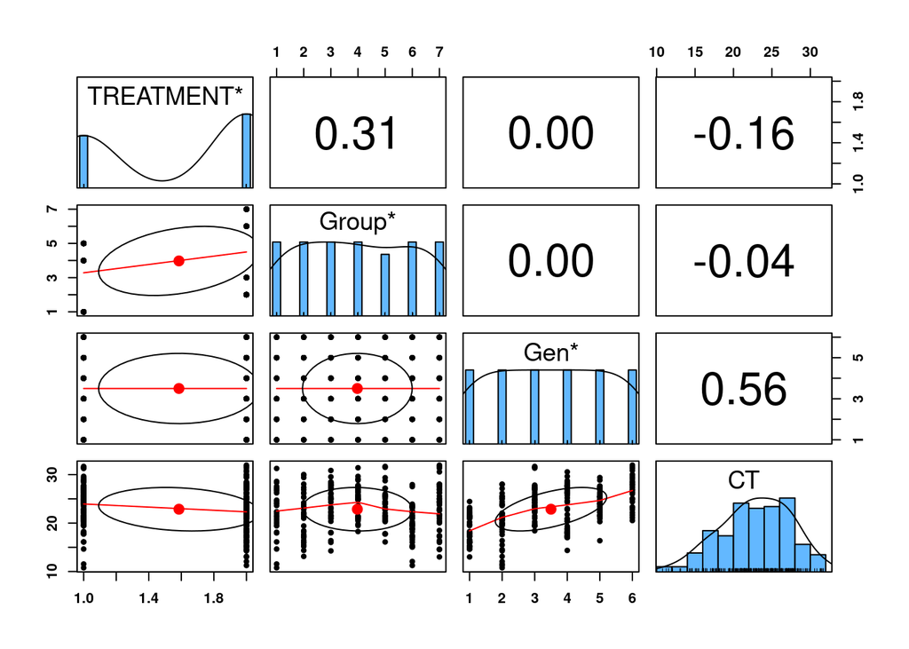

```r
pairs.panels(exp_gen[,4:7], method = "pearson", hist.col = "steelblue1",  density = TRUE, font=2)
```

Existe interaccion entre Grupo y Gen, y existe correlación positiva entre Tratamiento y Grupo, y entre CT y Gen con el mayor indice de correlacion, debido a que estas variables están estrechamente relacionadas, mientras que CT se correlaciona de forma negativa con tratamiento y grupo.

Observacion Parcial: La coinfección con caligus favorece la respuesta inmune, mientras que los peces vacunados e infectados con P. salmonis sin caligus presentan los mas bajos niveles de expresión de genes relacionados al sistema inmune.

```r
table(sobrevivencia$Protein)
```

```
##
## Control      IB
##      13      39
```

```r
knitr::kable(table(sobrevivencia$Protein, sobrevivencia$Hours), caption= "Tabla 4. Datos de Supervivencia por administracion de Proteinas Recombiante por hora")
```

Tabla 4. Datos de Supervivencia por administracion de Proteinas Recombiante por hora

|  | 20 | 23 | 30 | 42 | 48 | 66 | 100 |
| --- | --- | --- | --- | --- | --- | --- | --- |
| Control | 8 | 1 | 0 | 0 | 0 | 0 | 4 |
| IB | 2 | 1 | 1 | 1 | 1 | 1 | 32 |

```r
prop.table(table(sobrevivencia$Protein))
```

```
##
## Control      IB
##    0.25    0.75
```

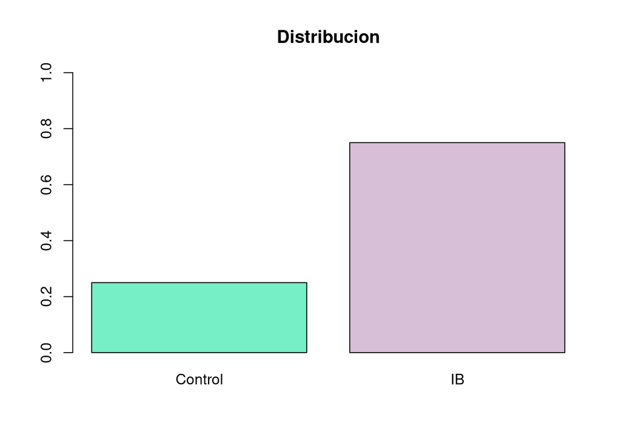

```r
barplot(prop.table(table(sobrevivencia$Protein)),
        col = c("aquamarine2", "thistle"),
        ylim = c(0, 1),
        main = "Distribucion")
```

Los datos no estan balanceados. IB representa el 75% de los datos

```r
table(Sobrevivencia_CI$Protein)
```

```
##
##    CCL4 control    IL-6    iRFP   TNF-a
##      13      15      11      55      10
```

```r
prop.table(table(Sobrevivencia_CI$Protein))
```

```
##
##       CCL4    control       IL-6       iRFP      TNF-a
## 0.12500000 0.14423077 0.10576923 0.52884615 0.09615385
```

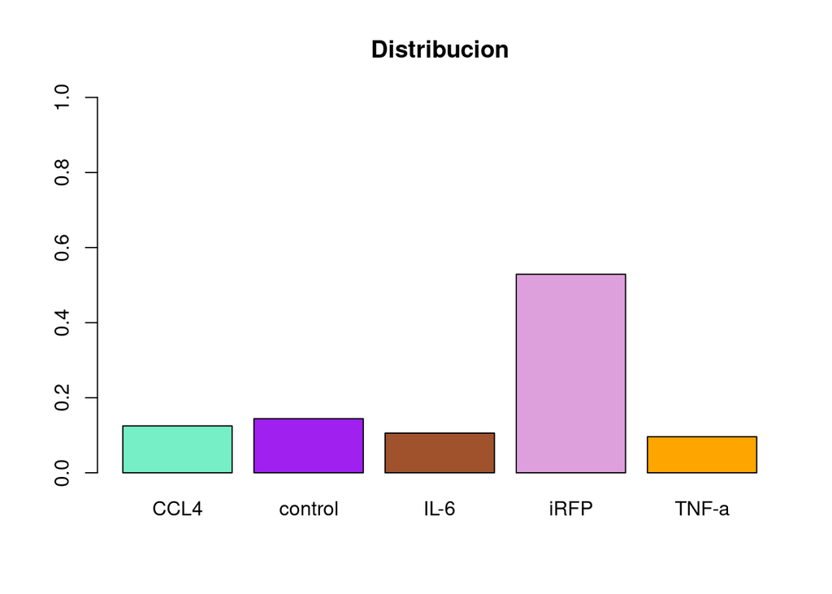

```r
barplot(prop.table(table(Sobrevivencia_CI$Protein)),
        col = c("aquamarine2", "purple", "sienna", "plum","orange"),
        ylim = c(0, 1),
        main = "Distribucion")
```

Los datos no están balanceados, TNF-a está representado por un 9,6% e iRFP representa casi el 50%

# Analisis de sobreviencia

H0= Los CI no influyen en la sobreviencia de los peces H1= Los CI favorecen la sobreviencia de los peces

```r
Su_IB_factor<-as.factor(sobrevivencia$Protein)
IB_surv <- Surv(sobrevivencia$Hours, sobrevivencia$Sobrevivencia)
class(IB_surv)
```

```
## [1] "Surv"
```

```r
IB_surv
```

```
##  [1]  20   20   20   20   20   20   20   20   23  100+ 100+ 100+ 100+  23   42
## [16] 100+ 100+ 100+ 100+ 100+ 100+ 100+ 100+ 100+ 100+  20   30  100+ 100+ 100+
## [31] 100+ 100+ 100+ 100+ 100+ 100+ 100+ 100+ 100+  20   48   66  100+ 100+ 100+
## [46] 100+ 100+ 100+ 100+ 100+ 100+ 100+
```

```r
IB = survfit(formula=Surv(sobrevivencia$Hours,  sobrevivencia$Sobrevivencia) ~ Protein, data=sobrevivencia, na.action= na.exclude,type="kaplan-meier")
class(IB)
```

```
## [1] "survfit"
```

```r
summary(IB)
```

```
## Call: survfit(formula = Surv(sobrevivencia$Hours, sobrevivencia$Sobrevivencia) ~
##     Protein, data = sobrevivencia, na.action = na.exclude, type = "kaplan-meier")
##
##                 Protein=Control
##  time n.risk n.event survival std.err lower 95% CI upper 95% CI
##    20     13       8    0.385   0.135        0.193        0.765
##    23      5       1    0.308   0.128        0.136        0.695
##
##                 Protein=IB
##  time n.risk n.event survival std.err lower 95% CI upper 95% CI
##    20     39       2    0.949  0.0353        0.882        1.000
##    23     37       1    0.923  0.0427        0.843        1.000
##    30     36       1    0.897  0.0486        0.807        0.998
##    42     35       1    0.872  0.0535        0.773        0.983
##    48     34       1    0.846  0.0578        0.740        0.967
##    66     33       1    0.821  0.0615        0.708        0.950
```

```r
dif_su_IB<- survdiff(formula = Surv(sobrevivencia$Hours, sobrevivencia$Sobrevivencia) ~ Protein, data= sobrevivencia)
dif_su_IB
```

```
## Call:
## survdiff(formula = Surv(sobrevivencia$Hours, sobrevivencia$Sobrevivencia) ~
##     Protein, data = sobrevivencia)
##
##                  N Observed Expected (O-E)^2/E (O-E)^2/V
## Protein=Control 13        9     3.15     10.84      16.1
## Protein=IB      39        7    12.85      2.66      16.1
##
##  Chisq= 16.1  on 1 degrees of freedom, p= 6e-05
```

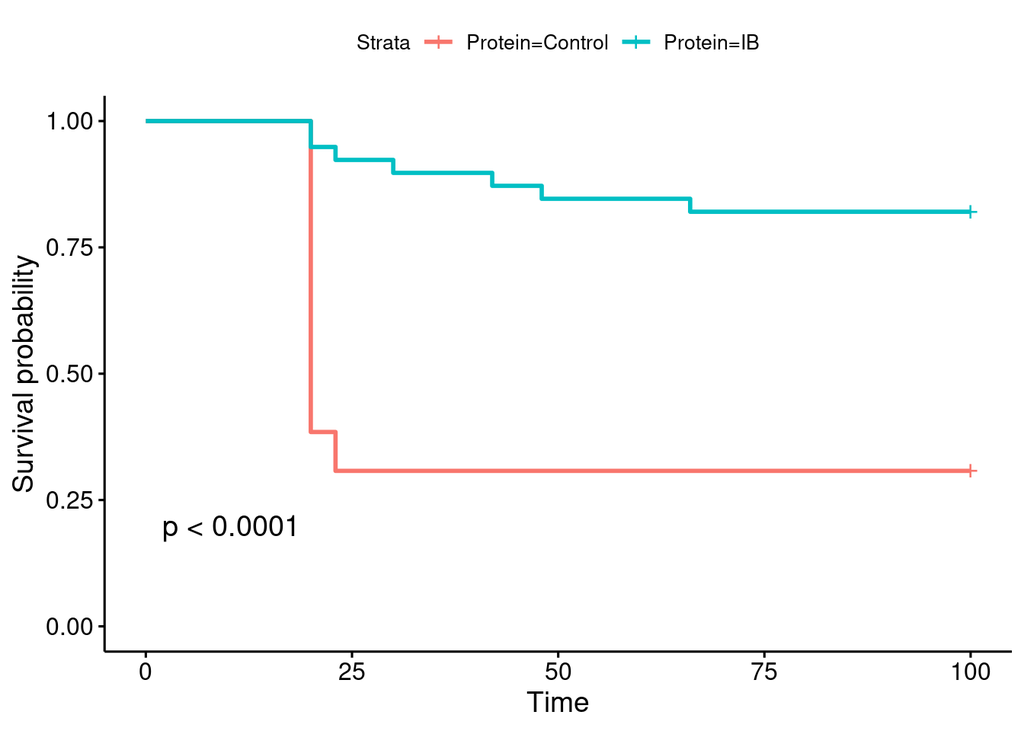

```r
ggsurvplot(survfit(Surv(sobrevivencia$Hours,sobrevivencia$Sobrevivencia) ~ Protein, data = sobrevivencia, na.action = na.exclude, type="kaplan-meier"),
pval = TRUE, conf.int = FALSE)
```

```r
Su_protein_factor<-as.factor(Sobrevivencia_CI$Protein)
CI_surv <- Surv(Sobrevivencia_CI$Hour, Sobrevivencia_CI$Sobrevivencia)
class(CI_surv)
```

```
## [1] "Surv"
```

```r
CI_surv
```

```
##   [1]  9   9  23  23  23  23  23  23  23  23  23  72  72  96+ 96+ 95+ 95+ 95+
##  [19] 95+ 95+ 95+ 95+ 95+ 95+ 95+ 96+ 96+ 96+ 96+ 96+ 96+ 96+ 96+ 96+ 96+ 96+
##  [37] 23  96+ 96+ 96+ 96+ 96+ 96+ 96+ 96+ 96+ 96+ 96+ 96+ 23  23  23  23  23
##  [55] 23  96+ 96+ 96+ 96+ 96+ 23  26  26  72  96+ 96+ 96+ 96+ 96+ 96+ 23  23
##  [73] 23  23  96+ 96+ 96+ 96+ 96+ 96+ 96+ 23  23  23  23  23  23  96+ 96+ 96+
##  [91] 96+ 96+ 96+ 96+ 23  26  26  72  96+ 96+ 96+ 96+ 96+ 96+
```

```r
ps = survfit(formula=Surv(Sobrevivencia_CI$Hour,  Sobrevivencia_CI$Sobrevivencia) ~
               Protein, data=Sobrevivencia_CI, na.action= na.exclude,type="kaplan-meier")
class(ps)
```

```
## [1] "survfit"
```

```r
summary(ps)
```

```
## Call: survfit(formula = Surv(Sobrevivencia_CI$Hour, Sobrevivencia_CI$Sobrevivencia) ~
##     Protein, data = Sobrevivencia_CI, na.action = na.exclude,
##     type = "kaplan-meier")
##
##                 Protein=CCL4
##         time       n.risk      n.event     survival      std.err lower 95% CI
##      23.0000      13.0000       1.0000       0.9231       0.0739       0.7890
## upper 95% CI
##       1.0000
##
##                 Protein=control
##  time n.risk n.event survival std.err lower 95% CI upper 95% CI
##     9     15       2    0.867  0.0878       0.7106        1.000
##    23     13       9    0.267  0.1142       0.1152        0.617
##    72      4       2    0.133  0.0878       0.0367        0.484
##
##                 Protein=IL-6
##      time n.risk n.event survival std.err lower 95% CI upper 95% CI
##
##                 Protein=iRFP
##  time n.risk n.event survival std.err lower 95% CI upper 95% CI
##    23     55      18    0.673  0.0633        0.559        0.809
##    26     37       4    0.600  0.0661        0.484        0.745
##    72     33       2    0.564  0.0669        0.447        0.711
##
##                 Protein=TNF-a
##      time n.risk n.event survival std.err lower 95% CI upper 95% CI
```

```r
Su_protein_factor<-as.factor(Sobrevivencia_CI$Protein)
CI_surv <- Surv(Sobrevivencia_CI$Hour, Sobrevivencia_CI$Sobrevivencia)
class(CI_surv)
```

```
## [1] "Surv"
```

```r
CI_surv
```

```
##   [1]  9   9  23  23  23  23  23  23  23  23  23  72  72  96+ 96+ 95+ 95+ 95+
##  [19] 95+ 95+ 95+ 95+ 95+ 95+ 95+ 96+ 96+ 96+ 96+ 96+ 96+ 96+ 96+ 96+ 96+ 96+
##  [37] 23  96+ 96+ 96+ 96+ 96+ 96+ 96+ 96+ 96+ 96+ 96+ 96+ 23  23  23  23  23
##  [55] 23  96+ 96+ 96+ 96+ 96+ 23  26  26  72  96+ 96+ 96+ 96+ 96+ 96+ 23  23
##  [73] 23  23  96+ 96+ 96+ 96+ 96+ 96+ 96+ 23  23  23  23  23  23  96+ 96+ 96+
##  [91] 96+ 96+ 96+ 96+ 23  26  26  72  96+ 96+ 96+ 96+ 96+ 96+
```

```r
ps = survfit(formula=Surv(Sobrevivencia_CI$Hour,  Sobrevivencia_CI$Sobrevivencia) ~
               Protein, data=Sobrevivencia_CI, na.action= na.exclude,type="kaplan-meier")
class(ps)
```

```
## [1] "survfit"
```

```r
summary(ps)
```

```
## Call: survfit(formula = Surv(Sobrevivencia_CI$Hour, Sobrevivencia_CI$Sobrevivencia) ~
##     Protein, data = Sobrevivencia_CI, na.action = na.exclude,
##     type = "kaplan-meier")
##
##                 Protein=CCL4
##         time       n.risk      n.event     survival      std.err lower 95% CI
##      23.0000      13.0000       1.0000       0.9231       0.0739       0.7890
## upper 95% CI
##       1.0000
##
##                 Protein=control
##  time n.risk n.event survival std.err lower 95% CI upper 95% CI
##     9     15       2    0.867  0.0878       0.7106        1.000
##    23     13       9    0.267  0.1142       0.1152        0.617
##    72      4       2    0.133  0.0878       0.0367        0.484
##
##                 Protein=IL-6
##      time n.risk n.event survival std.err lower 95% CI upper 95% CI
##
##                 Protein=iRFP
##  time n.risk n.event survival std.err lower 95% CI upper 95% CI
##    23     55      18    0.673  0.0633        0.559        0.809
##    26     37       4    0.600  0.0661        0.484        0.745
##    72     33       2    0.564  0.0669        0.447        0.711
##
##                 Protein=TNF-a
##      time n.risk n.event survival std.err lower 95% CI upper 95% CI
```

```r
dif_su_CI<- survdiff(formula = Surv(Sobrevivencia_CI$Hour, Sobrevivencia_CI$Sobrevivencia) ~ Protein, data= Sobrevivencia_CI)
dif_su_CI
```

```
## Call:
## survdiff(formula = Surv(Sobrevivencia_CI$Hour, Sobrevivencia_CI$Sobrevivencia) ~
##     Protein, data = Sobrevivencia_CI)
##
##                  N Observed Expected (O-E)^2/E (O-E)^2/V
## Protein=CCL4    13        1     5.15     3.347      4.84
## Protein=control 15       13     4.30    17.587     25.84
## Protein=IL-6    11        0     4.45     4.454      6.29
## Protein=iRFP    55       24    20.04     0.782      2.09
## Protein=TNF-a   10        0     4.05     4.049      5.65
##
##  Chisq= 39.2  on 4 degrees of freedom, p= 6e-08
```

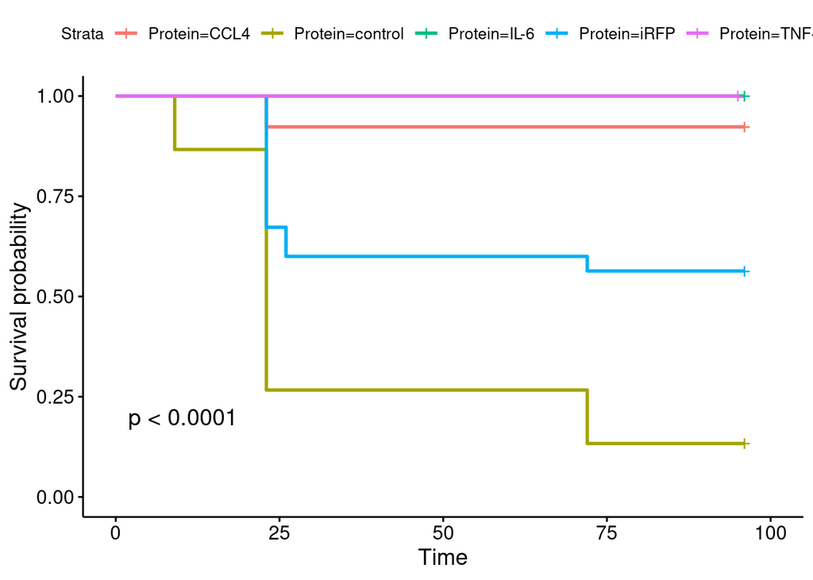

```r
ggsurvplot(survfit(Surv(Sobrevivencia_CI$Hour,Sobrevivencia_CI$Sobrevivencia) ~ Protein, data = Sobrevivencia_CI, na.action = na.exclude, type="kaplan-meier"),
pval = TRUE, conf.int = FALSE)
```

Los Cuerpos de inclusión favorecen la sobreviencia de los peces infectados con P. salmonis, y es la proteína TNFa e IL6 quien presenta los mejores resultados. Se rechaza H0

# Inferencia Estadística

La inferencia estadística permite deducir a parte de una muestra con N siginificativo (idealmente mayor a 30) y aleatorio el comportamiento de una población, en función de diversas variables que idealmente puedan influir en la población de estudios. Para ello se aplican diversos métodos estadísticos según la naturaleza de los datos que permiten determinar conclusiones sobre los parámetros de la población de datos. De la misma manera estudia también el grado de fiabilidad de los resultados extraídos del estudio.

Los métodos estadísticos se pueden dividir en dos grandes grupos, los métodos paramétricos que parten de una inferencia estadística de parámetros conocidos, aleatorios, de datos contínuos con distribución normal. Mientras que los métodos no parámetricos se aplican principalmente a datos ordinales o los que no tienen distribución normal.

Para saber si el efecto de las variables estudiadas tiene efecto o no sobre la población muestral se plantean dos hipótesis.

H0= es el estado “basal” de la población, en la cual no hay influencia de la variable (es) estudiada (s).

H1= plantea si la variable ejerce un efecto sobre la poblacion o inlcuso el tipo de efecto (positivo o negativo).

# Expresión Genica

Se determinan el promedio y la desviacion estandar de los CT

```r
CT<-exp_gen$CT
CT
```

```
##   [1] 22.29653 21.01943 16.11512 20.19989 14.63992 21.44565 22.60945 21.40910
##   [9] 21.23850 19.48206 19.74875 18.25261 16.10628 21.10453 21.41488 17.73109
##  [17] 17.80812 15.19897 16.40923 21.75521 15.93299 22.03757 16.08835 20.94974
##  [25] 16.57007 15.38774 17.25371 15.03765 16.05614 15.12181 21.48630 22.93979
##  [33] 23.20154 14.61024 17.40526 16.01288 17.20902 24.44913 13.01770 18.05649
##  [41] 16.01074 24.71909 23.61018 19.45787 22.32656 19.46952 24.20415 26.36576
##  [49] 25.41173 24.87241 25.93523 24.78368 25.08091 23.27505 31.68498 31.50198
##  [57] 27.17137 25.60305 18.40928 20.99411 24.19146 22.83339 23.74653 19.40997
##  [65] 27.21594 23.50408 22.53528 23.27216 20.27467 21.43717 19.87138 27.19947
##  [73] 26.97401 27.83568 22.63293 26.82558 27.01751 27.66764 31.33233 27.43473
##  [81] 24.33270 22.16242 27.06787 26.37680 17.96145 24.58062 18.10467 26.66134
##  [89] 29.64020 27.61353 27.46880 25.73322 26.94749 25.18450 17.78094 28.73350
##  [97] 24.28932 22.76034 20.82333 17.31639 17.26348 26.11589 14.35364 26.24133
## [105] 17.01978 27.71773 19.34151 18.76003 18.91784 17.00094 18.21095 17.44341
## [113] 27.71429 28.07142 28.38571 18.48197 20.42304 22.98638 21.74796 30.56178
```

[output cut: 16 more lines]

```r
CT_novacunados<-CT[1:102]
CT_vacunados<-CT[103:154]

mean(CT_novacunados)
```

```
## [1] 21.99831
```

```r
sd(CT_novacunados)
```

```
## [1] 4.372769
```

```r
mean(CT_vacunados)
```

```
## [1] 20.48095
```

```r
sd(CT_vacunados)
```

```
## [1] 4.486645
```

```r
CT_exp_gen<-
  knitr::kable(c(
    CT_novacunados_mean = mean(CT_novacunados),
    CT_novacunados_sd = sd(CT_novacunados),
    CT_vacunados_mean = mean(CT_vacunados),
    CT_vacunados_sd = sd(CT_vacunados)),
    caption= "Tabla 1. Promedio y Desviación estándar de los CT de expresión génica para salmones vacunados y no vacuandos"
    )
CT_exp_gen
```

Tabla 1. Promedio y Desviación estándar de los CT de expresión génica para salmones vacunados y no vacuandos

|  | x |
| --- | --- |
| CT_novacunados_mean | 21.998312 |
| CT_novacunados_sd | 4.372769 |
| CT_vacunados_mean | 20.480946 |
| CT_vacunados_sd | 4.486645 |

El promedio de CT de peces vacunados y no vacunados es similar y la Desviación estándar en ambos grupos es muy estrecha.

Se puede evaluar la correlación entre la variable treatment y CT o entre Group y CT

```r
Group_factor<-as.factor(exp_gen$Group)
Group_numeric<-as.numeric(Group_factor)
Tratment_factor<-as.factor(exp_gen$TREATMENT)
Tratment_numeric<-as.numeric(Tratment_factor)
Tratment_CT<-cor(Tratment_numeric, exp_gen$CT)
Group_CT<-cor(Group_numeric, exp_gen$CT)
Gen_factor<-as.factor(exp_gen$Gen)
Gen_numeric<-as.numeric(Gen_factor)
Gen_CT<-cor(Gen_numeric, exp_gen$CT)

knitr::kable(c(
  Tratment_CT = cor(Tratment_numeric, exp_gen$CT),
    Group_CT= cor(Group_numeric, exp_gen$CT),
      Gen_CT= cor(Gen_numeric, exp_gen$CT)),
        caption= "Tabla 2. Correlación entre las variables tartamiento y CT y entre Grupo y CT"
    )
```

Tabla 2. Correlación entre las variables tartamiento y CT y entre Grupo y CT

|  | x |
| --- | --- |
| Tratment_CT | -0.1634143 |
| Group_CT | -0.0381755 |
| Gen_CT | 0.5571157 |

Las variables tratamiento y Grupo estan correlacionada negativamente con la expresión génica (CT), mientras que la variable Gen si esta relacionada un 56% con la variable CT

Para determinar la correlacion entre las variables de contrastan las hipótesis

H0= la variable Tratamiento no esta relacionada con CT H1= la vaiable Tratamiento y CT están relacionadas

```r
cor_T_CT<- cor.test(x=exp_gen$CT, y=, Tratment_numeric, method = ("pearson"), conf.level = 0.95)
 IC_cor_T_CT<- cor.test(exp_gen$CT, Tratment_numeric)$conf.int
 pander(cor_T_CT, caption="Prueba de hipótesis para el coeficiente de correlación entre Tratamiento y CT")
```

Prueba de hipótesis para el coeficiente de correlación entre Tratamiento y CT El valor de P es de 0,01 < a 0,05 por lo que se rechaza H0 y por lo tanto el Tratamiento si influye sobre el valor de CT, con un intervalo de confianza del 95%

| Test statistic | df | P value | Alternative hypothesis | cor |
| --- | --- | --- | --- | --- |
| -2.587 | 244 | 0.01025 * | two.sided | -0.1634 |

H0= la variable Grupo no esta relacionada con CT H1= la vaiable Grupo y CT están relacionadas

```r
cor_G_CT<- cor.test(x=exp_gen$CT, y=, Group_numeric, method = ("pearson"), conf.level = 0.95)
 IC_cor_G_CT<- cor.test(exp_gen$CT, Group_numeric)$conf.int
 pander(cor_G_CT, caption="Prueba de hipótesis para el coeficiente de correlación entre Grupo y CT")
```

Prueba de hipótesis para el coeficiente de correlación entre Grupo y CT Se acepta la H0 porque el valor de P es mayor a 0,05 por lo tanto las variables Grupo y CT no están relacionadas

| Test statistic | df | P value | Alternative hypothesis | cor |
| --- | --- | --- | --- | --- |
| -0.5968 | 244 | 0.5512 | two.sided | -0.03818 |

```r
cor_G_CT<- cor.test(x=exp_gen$CT, y=, Tratment_numeric, method = ("pearson"), conf.level = 0.95)
 IC_cor_T_CT<- cor.test(exp_gen$CT, Tratment_numeric)$conf.int
 pander(cor_T_CT, caption="Prueba de hipótesis para el coeficiente de correlación entre Tratamiento y CT")
```

Prueba de hipótesis para el coeficiente de correlación entre Tratamiento y CT

| Test statistic | df | P value | Alternative hypothesis | cor |
| --- | --- | --- | --- | --- |
| -2.587 | 244 | 0.01025 * | two.sided | -0.1634 |

H0= la variable Gen no esta relacionada con CT H1= la vaiable Gen y CT están relacionadas

```r
cor_Gen_CT<- cor.test(x=exp_gen$CT, y=, Gen_numeric, method = ("pearson"), conf.level = 0.95)
 IC_cor_Gen_CT<- cor.test(exp_gen$CT, Group_numeric)$conf.int
 pander(cor_Gen_CT, caption="Prueba de hipótesis para el coeficiente de correlación entre Gen y CT")
```

Prueba de hipótesis para el coeficiente de correlación entre Gen y CT Con el valor de p <<0,05, Se rechaza H0 por lo tanto la variable Gen y CT están corrlacionadas.

| Test statistic | df | P value | Alternative hypothesis | cor |
| --- | --- | --- | --- | --- |
| 10.48 | 244 | 1.856e-21 * * * | two.sided | 0.5571 |

Dado que la variable Gen parece ser la mas atractiva para este estudio, Se puede hacer un ANOVA para determinar si los Genes tienen diferencias significativas.

La técnica de análisis de varianza (ANOVA) permite separar la población en diferentes grupos (Gen o Tratamiento en este caso), sobre la media de una variable cuantitativa (CT). Es por lo tanto el test estadístico a emplear cuando se desea comparar las medias de dos o más grupos. Esta técnica puede generalizarse también para estudiar los posibles efectos de los factores sobre la varianza de una variable.

Previamente se determino que los datos estan balanceados Se puede hacer un histograma, y boxplot

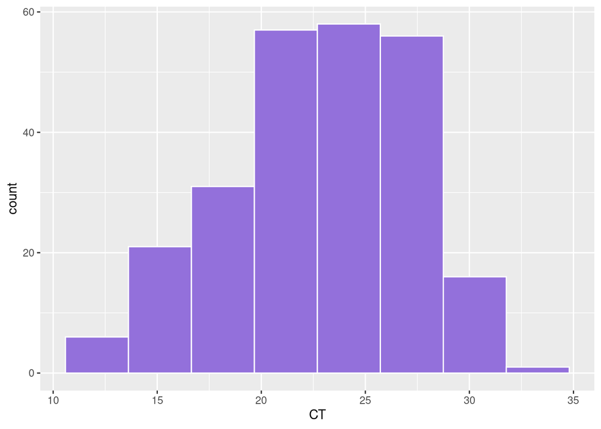

```r
CT_plot<- ggplot(exp_gen, aes(x=CT)) +
  geom_histogram(color="white", fill="mediumpurple", bins = 8)
CT_plot
```

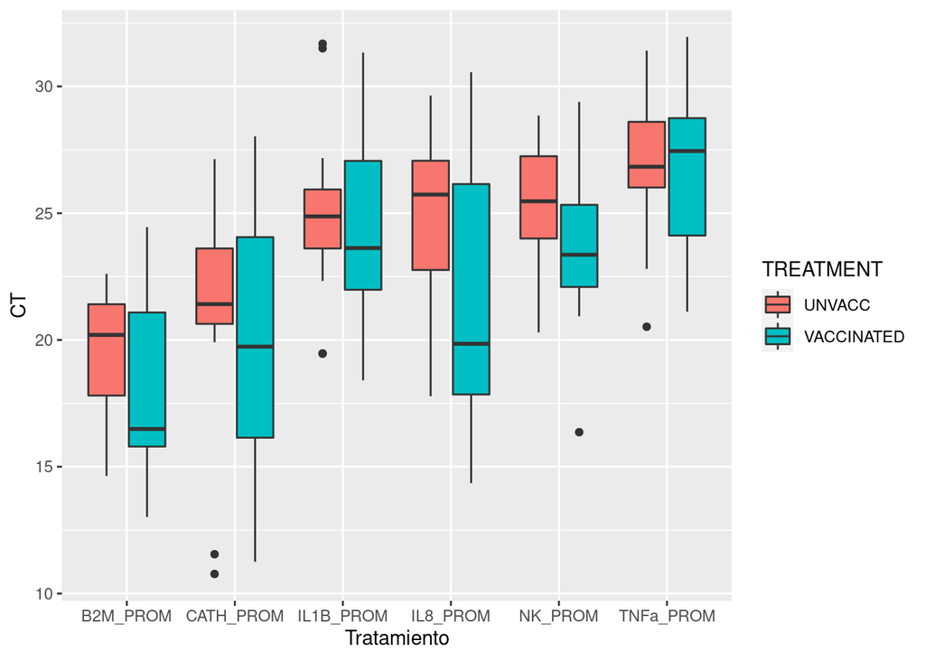

```r
T_Boxplot<-ggplot(data = exp_gen, aes(x=Gen, y=CT, fill=TREATMENT))+
  geom_boxplot()+
   labs(x="Tratamiento",y="CT")
T_Boxplot
```

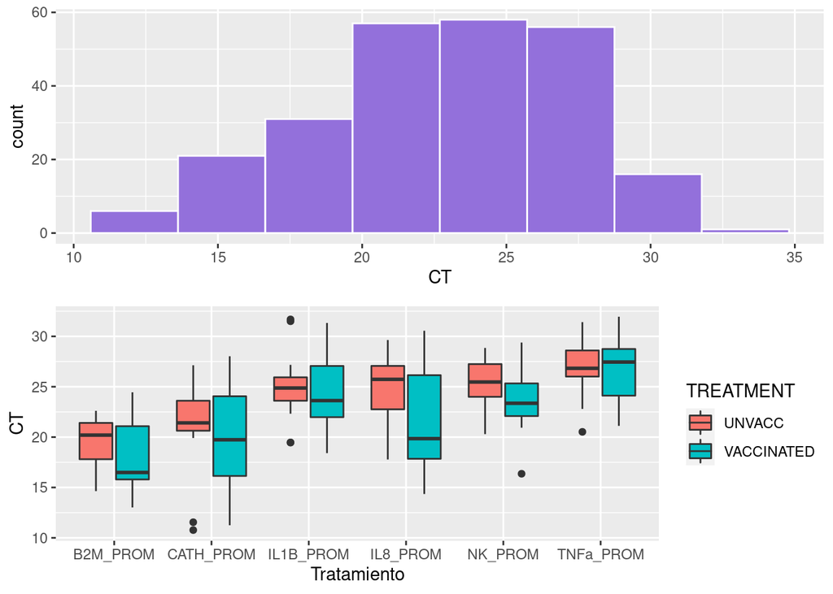

```r
grid.arrange(CT_plot, T_Boxplot, ncol=1, nrow =2)
```

En el histograma se observa un sesgo, por lo que pareciera que no hay distribucion normal.

Se deben evaluar los supuestos:

Supuestos: -Independencia de las observaciones: Prueba de Durwin-Watson -Normalidad (robusto). Alternativa: Kruskal-Wallis -Homocedasticidad u Homogeneidad de varianzas: Prueba de Levene - Normalidad: Prueba de Shapiro-Wilks(). Alternativa: prueba de Welch

Ruta de Trabajo: 1.- Primero evalúe independencia.. 2.- Luego homogeneidad de varianzas.. 3.- Finalmente normalidad..

Para hacer el ANOVA primero se ajusta modelo lineal

```r
lm_CT_Gen <- lm( Gen_numeric~exp_gen$CT )
lm_CT_Gen
```

```
##
## Call:
## lm(formula = Gen_numeric ~ exp_gen$CT)
##
## Coefficients:
## (Intercept)   exp_gen$CT
##     -1.3496       0.2122
```

Supuesto de Independencia:

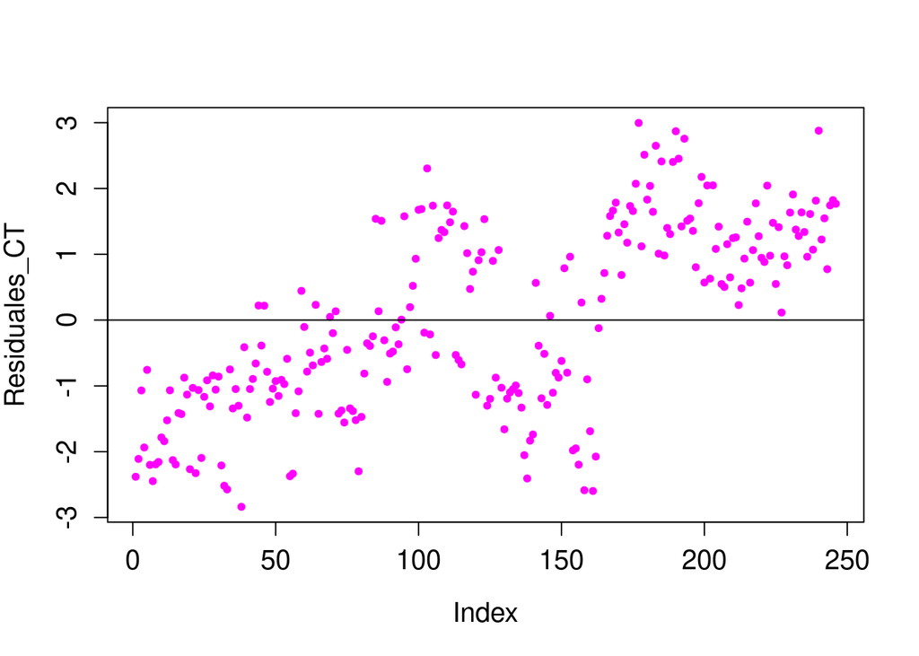

```r
plot(lm_CT_Gen$residuals, pch=20, col = "magenta", ylab="Residuales_CT",
cex.lab=1.25, cex.axis=1.25)
abline(0,0)
```

Según el analisis de residuales los datos no estan distribuidos de forma aleatoria y repartidos con equidad a través a lo largo del Eje Vertical

Hipótesis H0: Son independientes o no existe autocorrelación. H1: No son independientes y existe autocorrelación.

```r
dwtest(Gen_numeric ~ exp_gen$CT,
alternative = c("two.sided"),
iterations = 15) # library(lmtest)
```

```
##
##  Durbin-Watson test
##
## data:  Gen_numeric ~ exp_gen$CT
## DW = 0.50788, p-value < 2.2e-16
## alternative hypothesis: true autocorrelation is not 0
```

Hay correlación entre las variables CT y Gen, por lo tanto no hay independencia

```r
dwtest(Tratment_numeric ~ exp_gen$CT,
alternative = c("two.sided"),
iterations = 15) # library(lmtest)
```

```
##
##  Durbin-Watson test
##
## data:  Tratment_numeric ~ exp_gen$CT
## DW = 0.18972, p-value < 2.2e-16
## alternative hypothesis: true autocorrelation is not 0
```

Hay correlación entre Tratamiento y CT por tanto no hay independencia

Segundo supuesto

HOMOGENEIDAD DE VARIANZAS

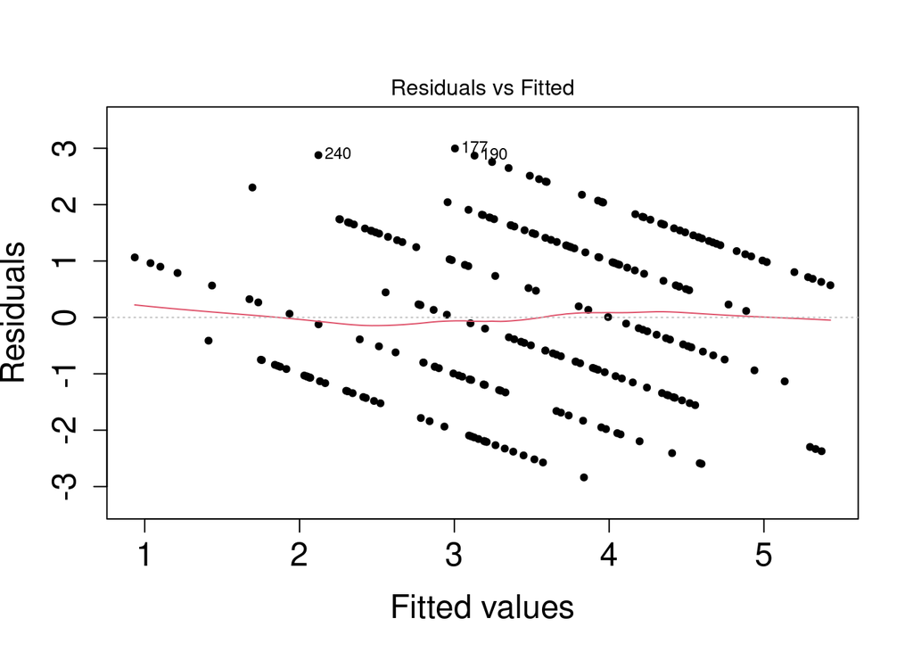

```r
plot(lm_CT_Gen, 1, pch=20, col = "black",
cex.lab=1.5, cex.axis=1.5, sub = "")
```

La línea rosa es un ajuste local de los residuos (ponderada localmente) que suaviza los puntos del diagrama de dispersión para facilitar la detección patrones en los residuos. La situación ideal es que esta línea roja sea una se asemeje a una recta horizonal centrada en cero.

HOMOGENEIDAD DE VARIANZAS: PRUEBA DE LEVENE

H0= la varianza de los grupos son iguales (existe homocedasticidad) H1= la varianza de los grupos son diferentes (existe heterocedasticidad)

```r
knitr::kable(leveneTest(y=exp_gen$CT, group = Gen_numeric,
center = "median"))
```

|  | Df | F value | Pr(>F) |
| --- | --- | --- | --- |
| group | 5 | 5.902826 | 3.63e-05 |
|  | 240 | NA | NA |

el valor de P es << a 0,05 por tanto hay diferencias significativas entre las varianzas de los diferentes genes

```r
knitr::kable(leveneTest(y=exp_gen$CT, group = Tratment_numeric,
center = "median"))
```

|  | Df | F value | Pr(>F) |
| --- | --- | --- | --- |
| group | 1 | 3.881461 | 0.0499529 |
|  | 244 | NA | NA |

NORMALIDAD: ANÁLISIS DE RESIDUALES

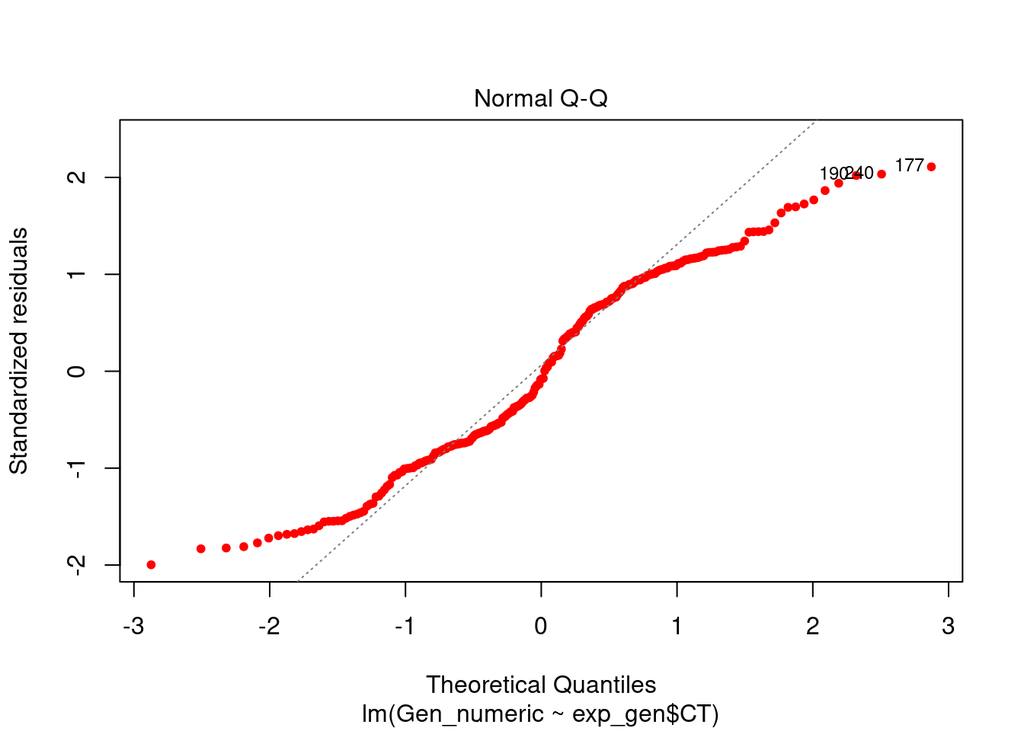

```r
plot(lm_CT_Gen, 2, pch=20, col = "red")
```

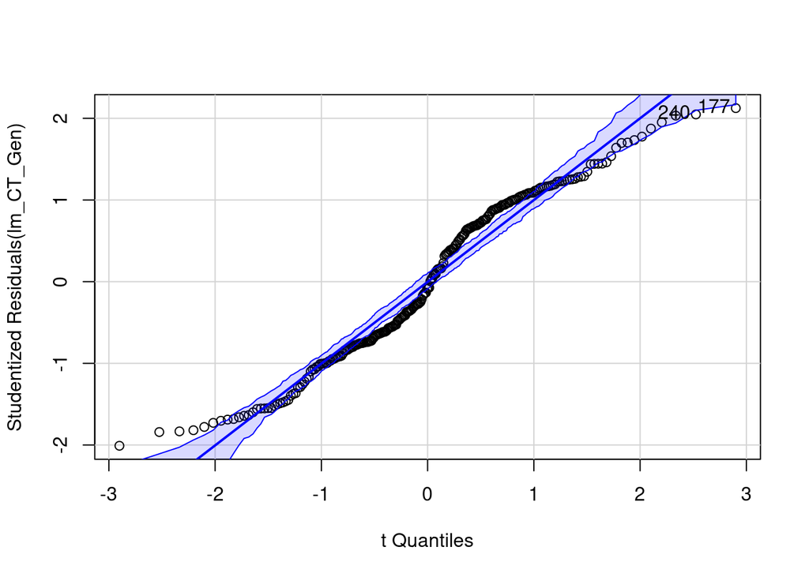

```
## [1] 177 240
```

```r
qqPlot(lm_CT_Gen)
```

El diagrama de dispersión (rojo) pareciera ajustarse a la recta indentidad, sin embargo luego no parecen estar dentro del rango (linea azul) ajustado a la recta de identidad, por lo que este ultimo gráfico sugiere que no hay una distribución normal de los residuos. Sin embargo, para comprobarlo se deben llevar a cabo pruebas estadísticas

NORMALIDAD: PRUEBA DE SHAPIRO-WILKS

H0: La distribución es normal. H1: La distribución no es normal.

```r
aov_residuals <- residuals(object = lm_CT_Gen)
shapiro.test(x= aov_residuals)
```

```
##
##  Shapiro-Wilk normality test
##
## data:  aov_residuals
## W = 0.96241, p-value = 4.724e-06
```

Se rechaza H0 y por lo tanto se concluye que los datos no tienen una distribución normal

Los datos no cumplen con los supuestos para poder hacer ANOVA por lo tanto se aplicará estadistica no parametrica, en este caso Kruskal-Wallis que es la mejor alternativa para ANOVA, pero al ser diferentes genes se puede aplicar PCA y PERMANOVA.

Pasos para realizar un PCA:

1. Estandarizar datos: Media 0 y varianza 1.
2. Calcular matriz de distancia (euclideana) de valores estandarizados.
3. Calcular valores y vectores propios (Eigenvalue y Eigenvector) de la matriz estandarizada.
4. Interpretación y gráficas biplot.

```r
D_PCA<-read_excel("Datos_expresion_genica.xlsx", sheet= "CT_PCA")
```

Se hace un analisis de correlacion entre las variables a estudiar (Gen)

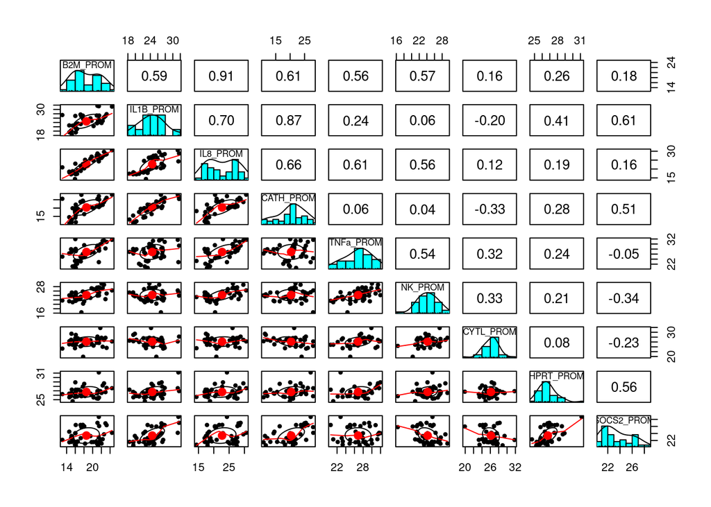

```r
pairs.panels(D_PCA[6:14])
```

```r
cor(D_PCA[6:14], method = "pearson")
```

```
##             B2M_PROM  IL1B_PROM  IL8_PROM  CATH_PROM  TNFa_PROM    NK_PROM
## B2M_PROM   1.0000000 0.59296273 0.9070998 0.61099631 0.55807769 0.57437411
## IL1B_PROM  0.5929627 1.00000000 0.6966689 0.87426065 0.23567703 0.06421823
## IL8_PROM   0.9070998 0.69666891 1.0000000 0.65719253 0.60922321 0.55927726
## CATH_PROM  0.6109963 0.87426065 0.6571925 1.00000000 0.06343511 0.04383705
## TNFa_PROM  0.5580777 0.23567703 0.6092232 0.06343511 1.00000000 0.54309863
## NK_PROM    0.5743741 0.06421823 0.5592773 0.04383705 0.54309863 1.00000000
## CYTL_PROM         NA         NA        NA         NA         NA         NA
## HPRT_PROM         NA         NA        NA         NA         NA         NA
## SOCS2_PROM        NA         NA        NA         NA         NA         NA
##            CYTL_PROM HPRT_PROM SOCS2_PROM
## B2M_PROM          NA        NA         NA
## IL1B_PROM         NA        NA         NA
## IL8_PROM          NA        NA         NA
## CATH_PROM         NA        NA         NA
## TNFa_PROM         NA        NA         NA
## NK_PROM           NA        NA         NA
## CYTL_PROM          1        NA         NA
## HPRT_PROM         NA         1         NA
## SOCS2_PROM        NA        NA          1
```

Ahora se debe elaborar un nuevo set de datos solo con las variables (los diferentes genes).

```r
D_PCA_new <- as.data.frame(D_PCA[,6:11])
row.names(D_PCA) <- D_PCA_new$Sample
head(D_PCA_new)
```

```
##   B2M_PROM IL1B_PROM IL8_PROM CATH_PROM TNFa_PROM  NK_PROM
## 1 22.29653  24.71909 27.06787  21.91724  31.27336 27.34866
## 2 15.19897  18.40928 17.31639  13.12336  26.88651 25.31795
## 3 21.01943  23.61018 26.37680  21.43025  28.60262 27.55538
## 4 16.11512  19.45787 17.96145  11.55011  27.19198 24.49215
## 5 16.40923  20.99411 17.26348  17.62220  22.15460 22.96295
## 6 20.19989  22.32656 24.58062  19.91136  26.79948 26.86915
```

Ahora se realiza el PCA para el nuevo set de datos

```r
exp_gen_pca <- prcomp(D_PCA_new, scale = TRUE)
exp_gen_pca
```

```
## Standard deviations (1, .., p=6):
## [1] 1.9093780 1.2247374 0.6931553 0.4603876 0.3045539 0.2629062
##
## Rotation (n x k) = (6 x 6):
##                  PC1         PC2         PC3         PC4         PC5
## B2M_PROM  -0.4865222  0.08261401 -0.16728541  0.66407772 -0.02624211
## IL1B_PROM -0.4059063 -0.44668425  0.18914898 -0.50417389 -0.46358695
## IL8_PROM  -0.5068055  0.04399237 -0.01226506  0.19944949 -0.39619446
## CATH_PROM -0.3850781 -0.51406832 -0.14720811 -0.08421971  0.72631714
## TNFa_PROM -0.3254339  0.47075608  0.74843821 -0.12824748  0.30709332
## NK_PROM   -0.2957906  0.55302373 -0.59519563 -0.49141529  0.07473656
##                   PC6
## B2M_PROM   0.53553602
## IL1B_PROM  0.36170673
## IL8_PROM  -0.73777522
## CATH_PROM -0.17649047
## TNFa_PROM  0.03959768
## NK_PROM    0.07307715
```

```r
summary(exp_gen_pca)
```

```
## Importance of components:
##                           PC1    PC2     PC3     PC4     PC5     PC6
## Standard deviation     1.9094 1.2247 0.69316 0.46039 0.30455 0.26291
## Proportion of Variance 0.6076 0.2500 0.08008 0.03533 0.01546 0.01152
## Cumulative Proportion  0.6076 0.8576 0.93770 0.97302 0.98848 1.00000
```

En la tabla se puede observar que B2M tiene el valor mar alto para el PC4, mientras que PC1 parece estar influenciado por IL8, y el PC2 por NK, , lo que indica que en estos componentes principales describe la mayor variación en estas variables. Haciendo un summary podemos ver que el PC1 parece explicar el 60% de la varianza. Es decir mas de la mitad de la información del conjunto de datos

Ahora se obtiene la varianza explicada de cada Componente

```r
get_eigenvalue(exp_gen_pca)
```

```
##       eigenvalue variance.percent cumulative.variance.percent
## Dim.1 3.64572453        60.762075                    60.76208
## Dim.2 1.49998172        24.999695                    85.76177
## Dim.3 0.48046421         8.007737                    93.76951
## Dim.4 0.21195678         3.532613                    97.30212
## Dim.5 0.09275310         1.545885                    98.84801
## Dim.6 0.06911966         1.151994                   100.00000
```

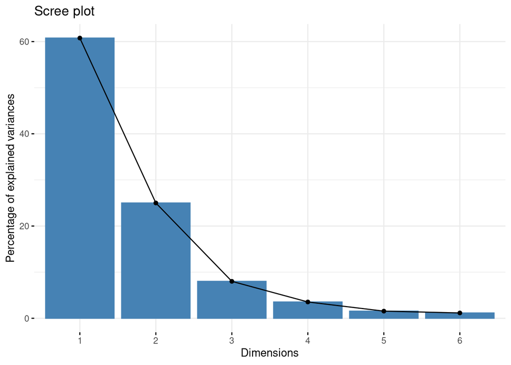

```r
fviz_eig(exp_gen_pca)
```

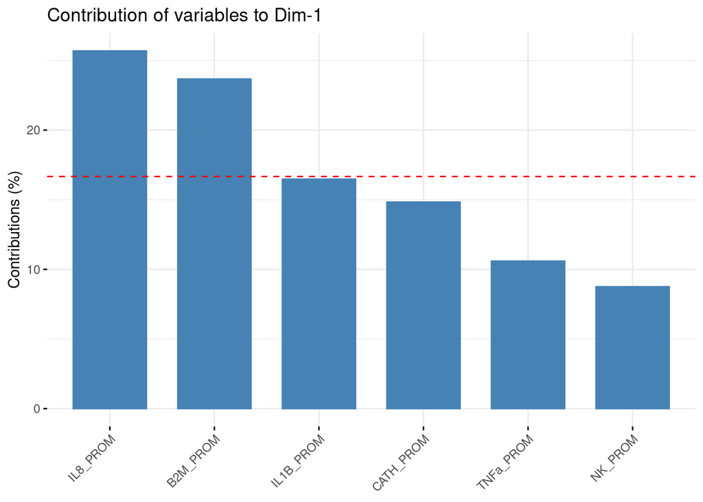

```r
fviz_contrib(exp_gen_pca, choice = "var", axes = 1, top = 10)
```

La línea roja discontinua indica el valor medio de contribución. Por tanto, el gen IL8 y B2M son los es la que más contribuyen a la PC1.

A continuacion se puede representar de forma grafica

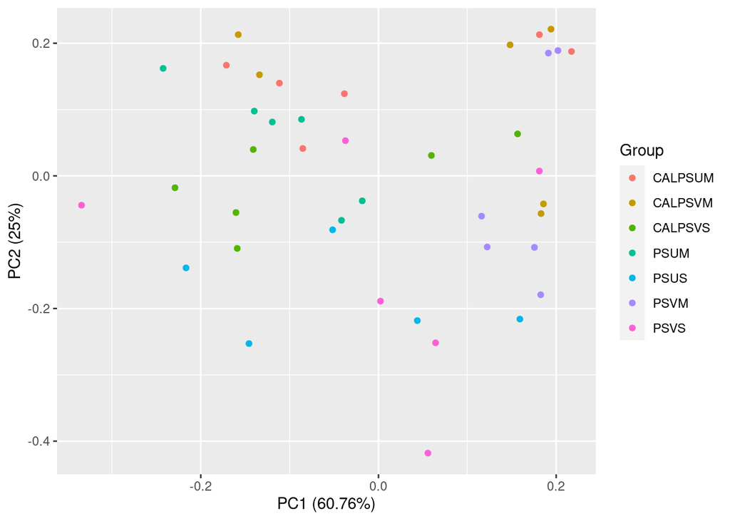

```r
exp_gen_pca.plot <- autoplot(exp_gen_pca,
                          data = D_PCA,
                          colour = "Group")

exp_gen_pca.plot
```

Para una mejor comprensión la función biplot() también se puede utilizar para trazar PCA.

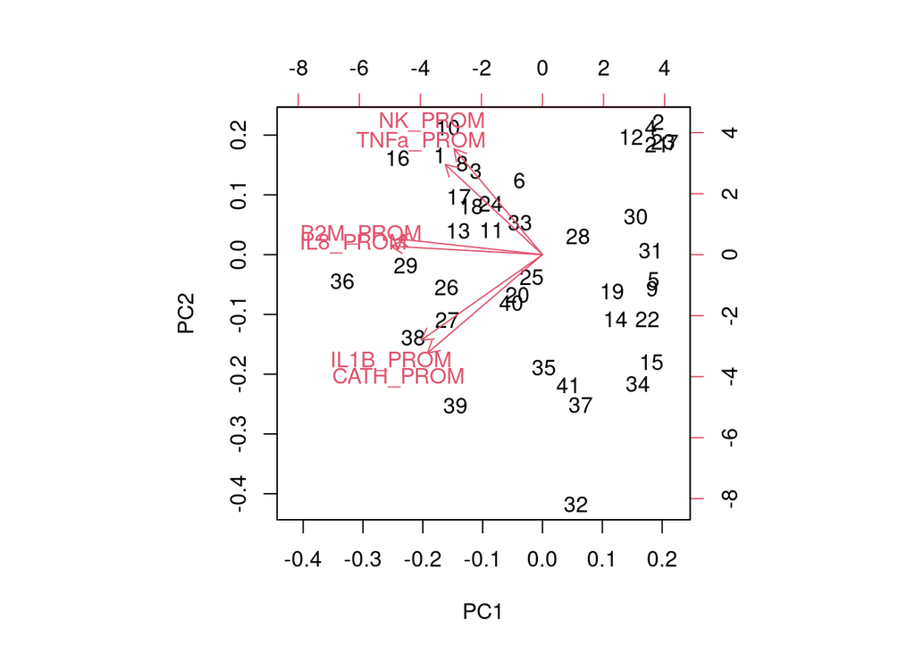

```r
biplot (exp_gen_pca, escala = 0 )
```

El eje X de la biplot representa el primer componente principal donde IL8 y BM2 convergen y explican el PC1, mientras que el PC2 está explicado por CATH, IL1B, TNFa y NK.

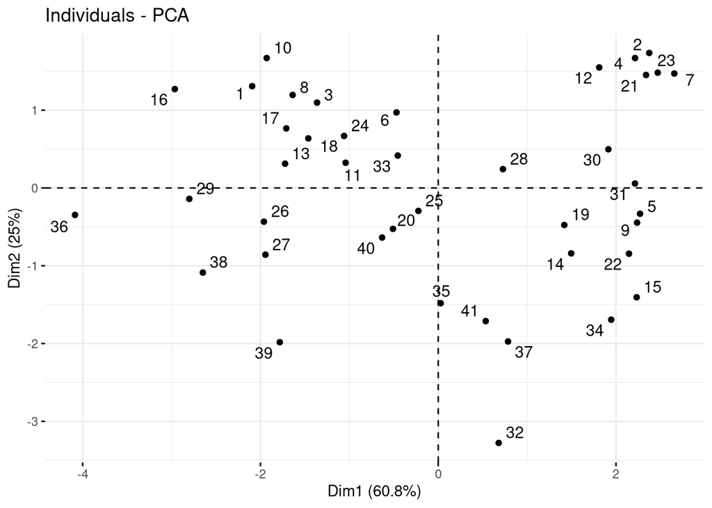

```r
fviz_pca_ind(exp_gen_pca, repel = TRUE) # repel= TRUE evita que se solape el nombre de los sitios
```